# 警务数据分析报告——24小时时间段内车流量

作者：李春燕

时间：2018年9月8日

**以下图示分析了24小时时间段内的车流量，4幅图片分别选取了不同时期车辆数据（以某小区的一个出入口为例）。**

## 1 春节假期期间24小时时间段车流量

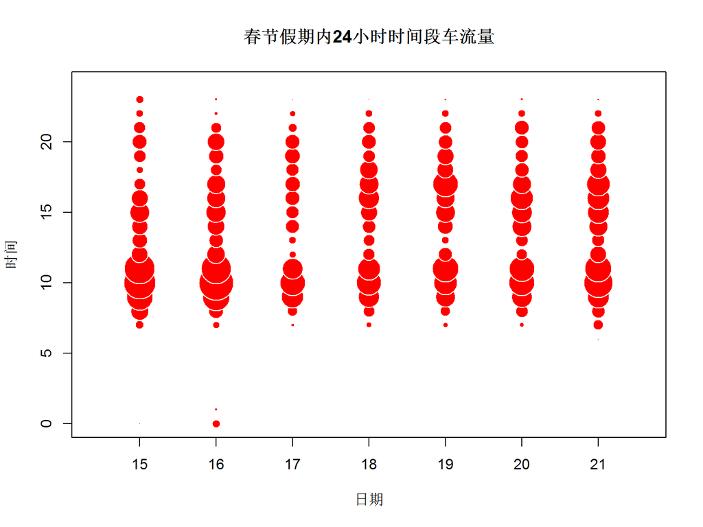

上图选取了2018年春节假期内的数据进行分析，横轴代表日期，表示假期从2018/2/15开始到2018/2/21结束；纵轴代表时间，表示0点到23点各个时间段；图中每一天的每个时间段对应一个点，点的大小表示这个时间段内车流数量多少；从图上可以看出春节假期内车辆进出主要集中在上午10点前后（8点-12点）和15点前后（14点-16点），10点前后车辆更多一些，其它时间段车辆进出较少，假期最后一天车辆进出相对假期前期要多。

## 2 元旦假期期间24小时时间段车流量

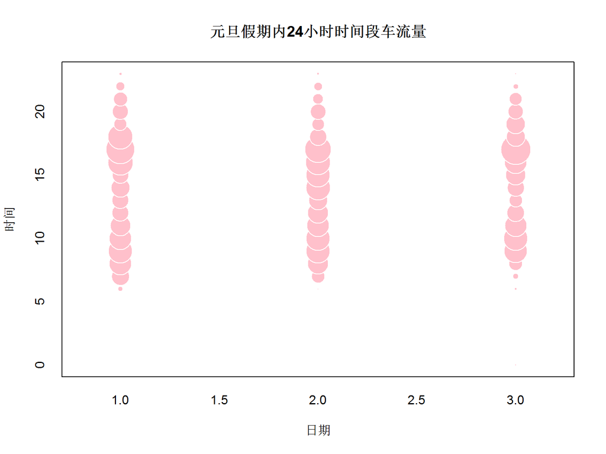

上图选取了2018年元旦假期内的数据进行分析，横轴代表假期的第1天至第3天，纵轴和点的代表意义同上；图中显示在假期的第1天和第3天，车辆出入集中在10点和16点，而假期中间（第2天），8点-17点内车辆进出量比较平均，且整体出入量比前后两天多。

## 3 每周24小时时间段内车流量

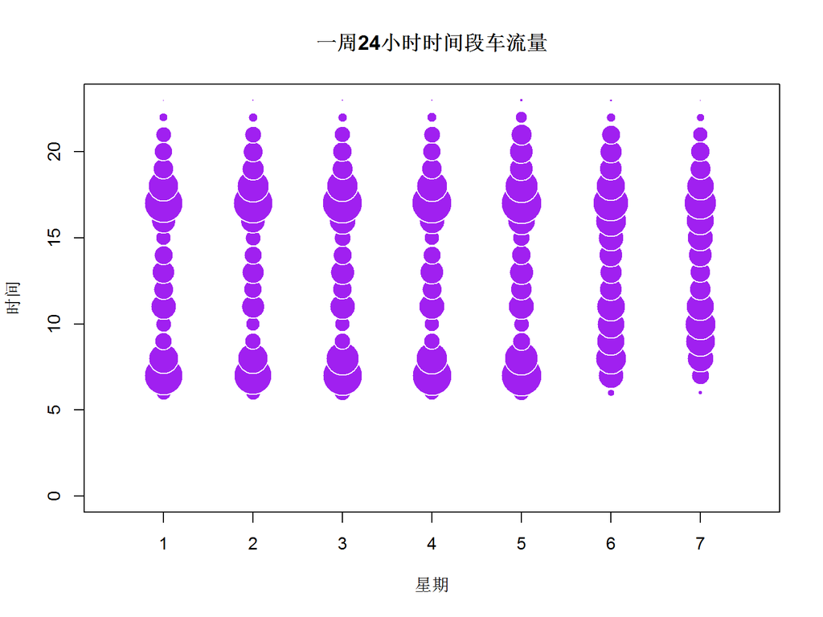

## 4 所有历史数据24小时时间段车流量

[figure not shown]

**总结：工作日车辆进出集中在早7点和晚5点，这两个时间为上下班高峰期；短期小假内车辆进出总量比工作日多，且在早晚8点之间分布比较平均；春节长假车辆进出总量较平时少，且更多集中在8点-12点，还有数量相对较少的集中在14点-16点，这两个时间段也是春节走亲访友的最佳时间。**